# 11/15 : 2-B-II

ABT-MSE Operating model fitting report

Tom Carruthers

July 11, 2019

# 1 Operating model scenario

2: West: B-H h=0.6 all years, East: B-H h=0.7 all years  
B: Older spawning, Low M  
II: High E-tag wt

# 2 Area definitions

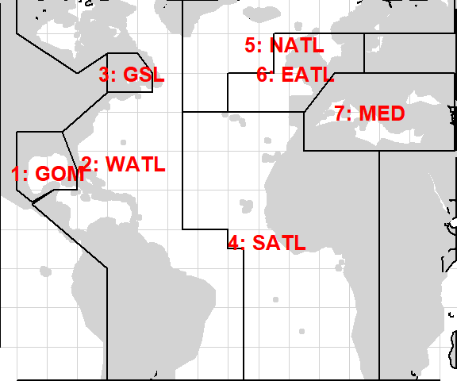

Figure 1. Area definitions for operating model

# 3 Fits to CPUE indices

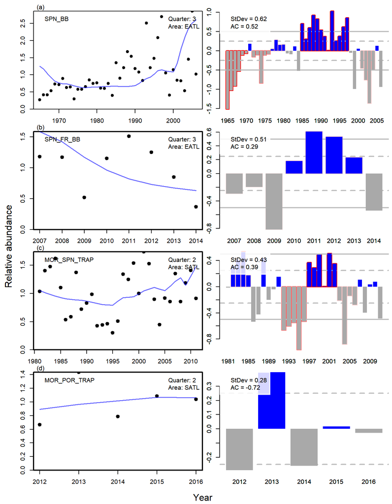

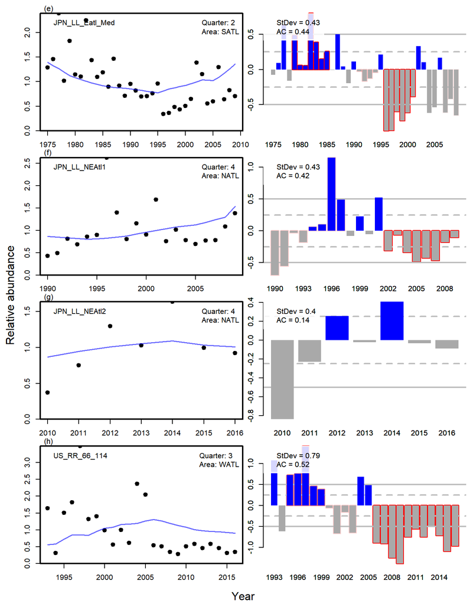

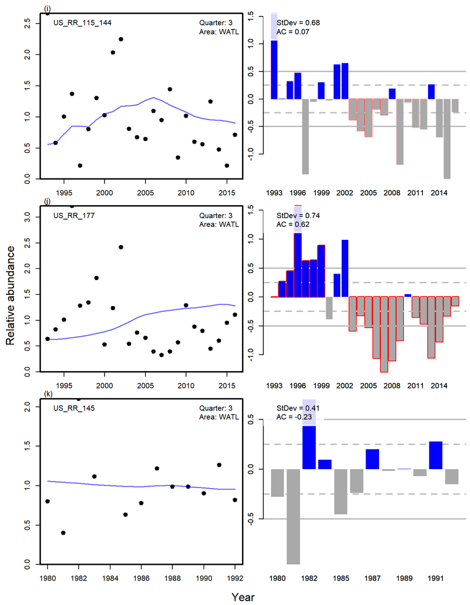

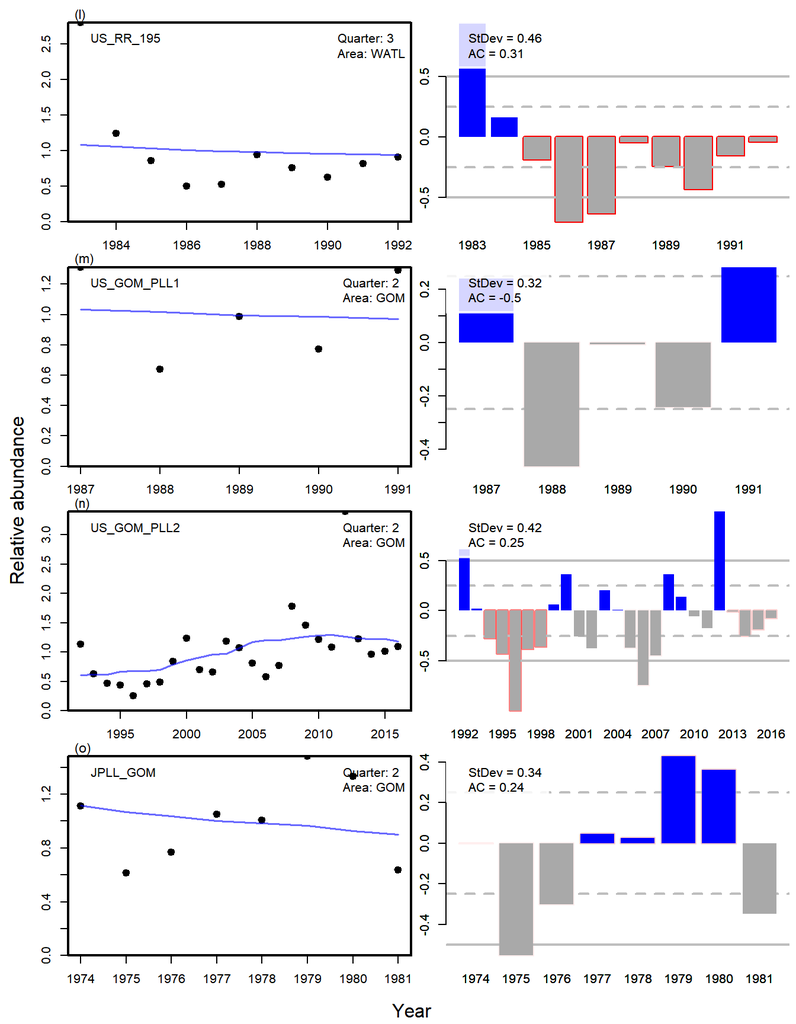

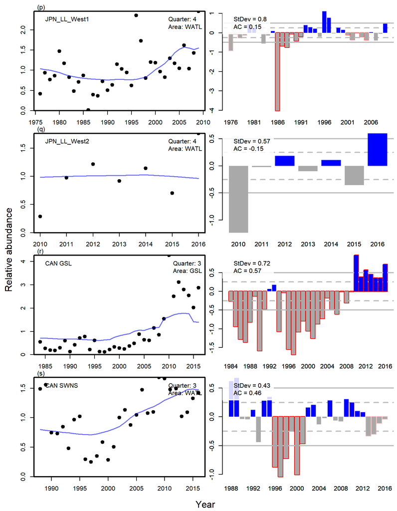

Figure 2. Operating model fits to CPUE indices. Each row corresponds with an index. The left-hand panels show the normalized (log index has mean 0) observed (black dots) and model predicted (blue line) indices. The right-hand panels show the log devitations (the observation model is log-normal) including the residual standard deviation (StDev) and lag-1 autocorrelation in residuals (AC). Runs of positive or negative residuals are highlighted with a red border. The dashed and solid horizontal grey lines are the same on each plot - the scale of y-axis varies among indices for these plots.

# 4 Fits to FI indices

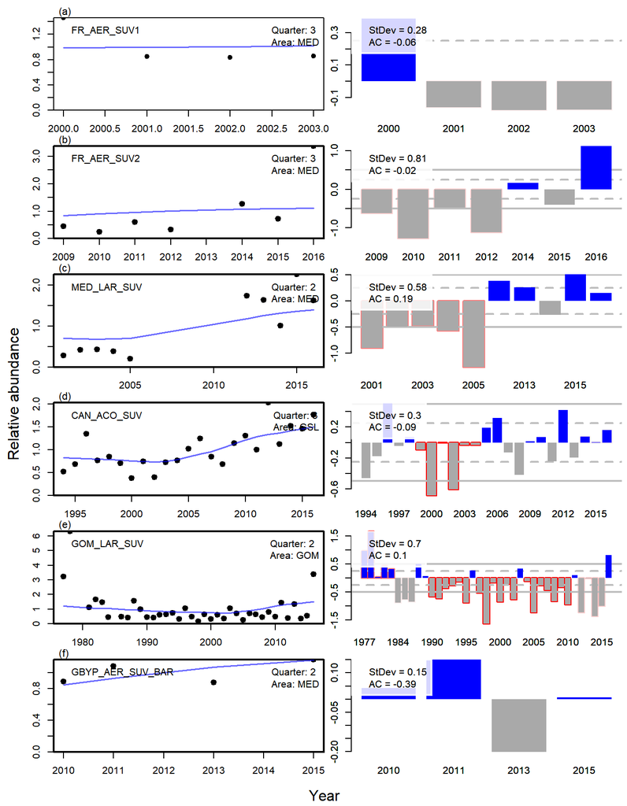

Figure 3. Operating model fits to fishery-independent indices. Each row corresponds with an index. The left-hand panels show the normalized (log index has mean 0) observed (black dots) and model predicted (blue line) indices. The right-hand panels show the log devitations (the observation model is log-normal) including the residual standard deviation (StDev) and lag-1 autocorrelation in residuals (AC). Runs of positive or negative residuals are highlighted with a red border. The dashed and solid horizontal grey lines are the same on each plot - the scale of y-axis varies among indices for these plots.

# 5 Spawning biomass

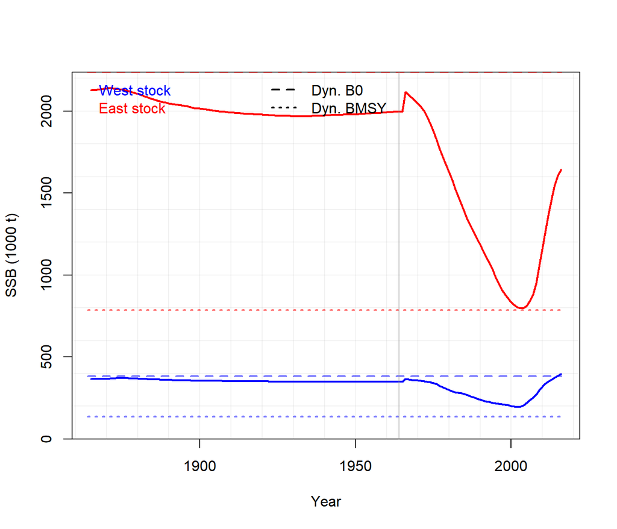

Figure 4a. Historical spawning biomass. Dynamic unfished spawning biomass (Dyn. B0) is calculated using year-specific estimates of unfished recruitment (depending on which R0 phase the model is in) assuming that there was zero fishing (ie it lags shifts in productivity). Dynamic BMSY is a fixed fraction of B0 based on the most recent estimates of BMSY relative to unfished (the steepness parameter assumed for 2016). Since in some operating models, R0 is changing over time, the maximum achievable level of stock biomass is also changing and keeping track of dynamic B0 provide a realistic yardstick for evaluating management performance.

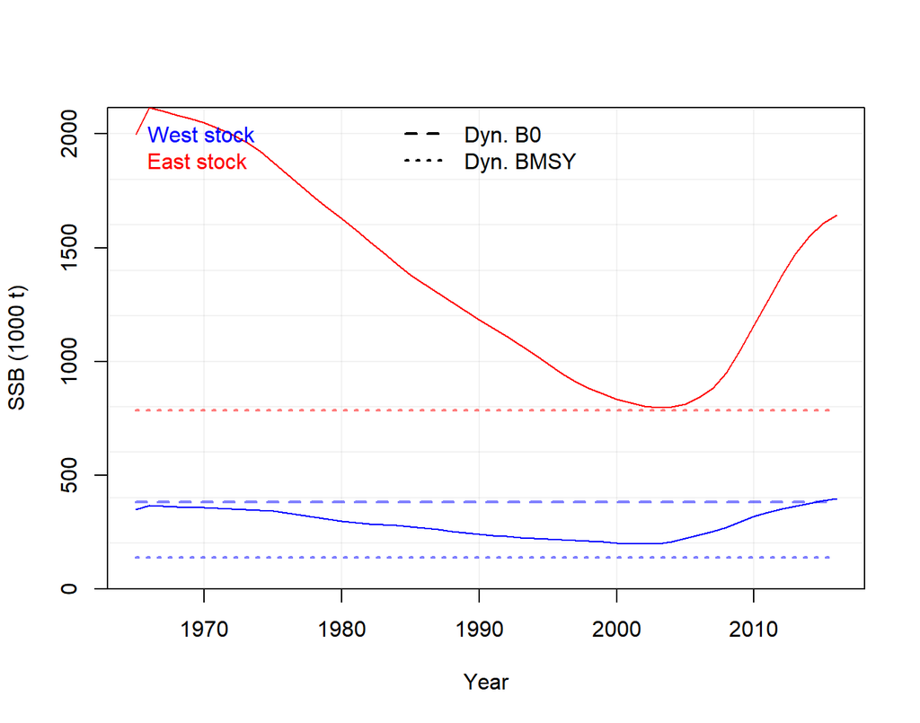

Figure 4b. Recent spawning biomass. Dynamic unfished spawning biomass (Dyn. B0) is calculated using year-specific estimates of recruitment strength assuming that there was zero fishing (ie it lags shifts in productivity). Dynamic BMSY is a fixed fraction of B0 based on the most recent estimates of BMSY relative to unfished.

# 6 Assessment comparison

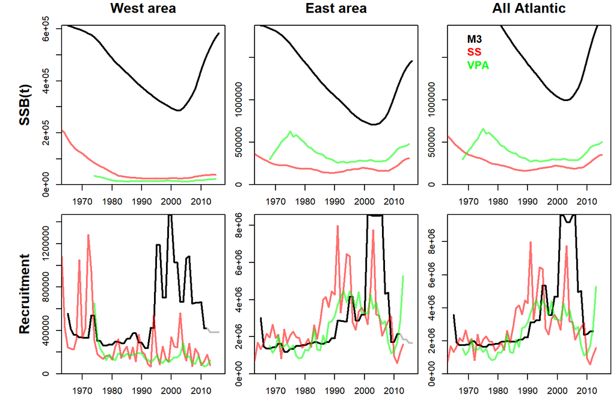

# 7 Stock-recruitment relationships

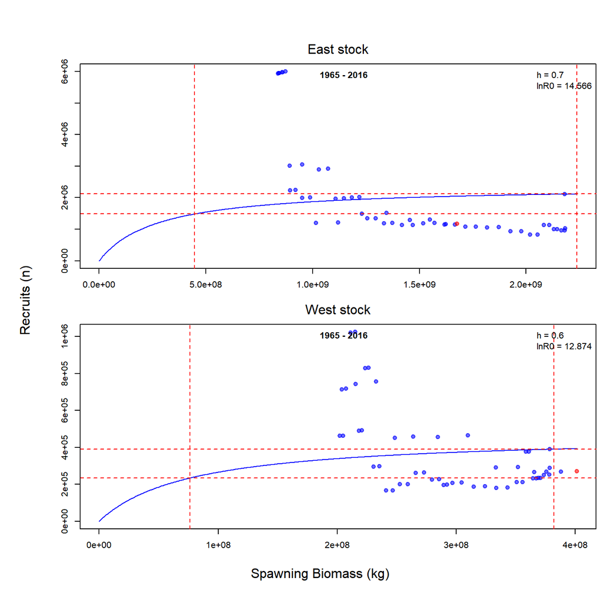

Figure 6. Model predicted spawning stock biomass and recruitment. h is the assumed value of steepness, lnR0 is the log unfished recruitment. The red point is the most recent SSB-Recruitment estimate.

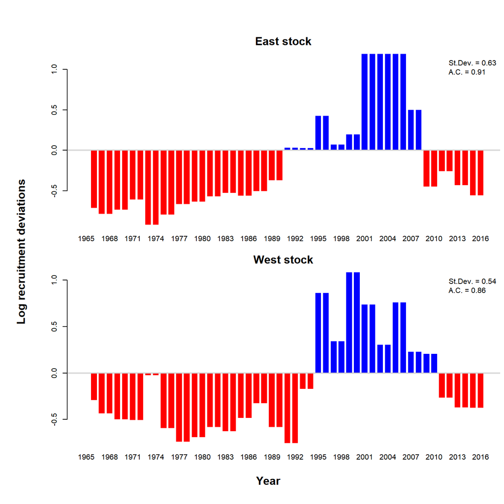

Figure 6. Recruitment deviations (log) for each stock-recruitment curve. Recruitment deviations are modelled for two-year time blocks. Blue bars represent positive deviations where the estimated recruitment is higher than the mean value predicted from the stock-recruitment curve. Red bars represent negative deviations. ‘St.Dev’. and ‘A.C’. refer to the Standard Deviation and lag-1 (assuming each block is a time period) autocorrelation in recruitment deviations.

# 8 MSY reference points

Table 1a. 2016 Reference points by area. MSY and BMSY numbers are in tons. Biomass figures (BMSY, B0) refer to Spawning Stock Biomass. Stock depletion refers to spawning stock biomass relative to ‘dynamic B0’ (a running calculation of unfished stock size accounting for shifts in recruitment). Similarly, BMSY is calculated as a dynamic quantity relating to ‘dynamic B0’.

|  | MSY | BMSY | BMSY_B0 | B_BMSY | Dep |
| --- | --- | --- | --- | --- | --- |
| East area | 31181 | 695745 | 0.351 | 2.110 | 0.741 |
| West area | 10678 | 225797 | 0.354 | 2.646 | 0.939 |

Table 1b. 2016 Reference points by stock. MSY and BMSY numbers are in tons. Biomass figures (BMSY, B0) refer to Spawning Stock Biomass. Fishing rate figures (FMSY, F) are phrased as apical Fs (F on the most selected length class). Stock depletion refers to spawning stock biomass relative to ‘dynamic B0’ (a running calculation of unfished stock size accounting for shifts in recruitment). Similarly BMSY is calculated as a dynamic quantity relating to ‘dynamic B0’.

|  | MSY | FMSY | BMSY | BMSY_B0 | F_FMSY | B_BMSY | Dep |
| --- | --- | --- | --- | --- | --- | --- | --- |
| East stock | 35159 | 0.059 | 785529 | 0.351 | 0.209 | 2.093 | 0.735 |
| West stock | 6700 | 0.054 | 136013 | 0.356 | 0.081 | 2.921 | 1.040 |

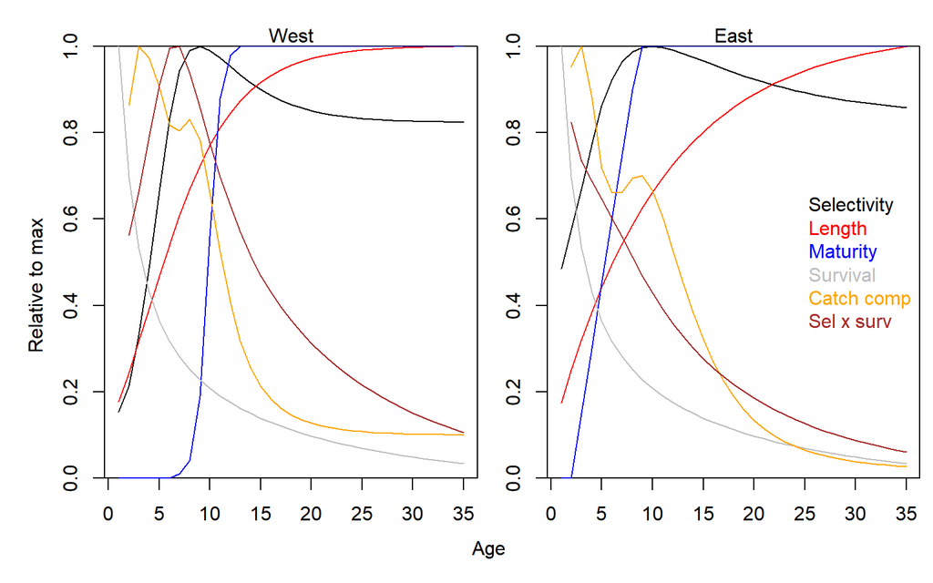

Figure 7. Age-specific quantities determining 2016 MSY reference points. Survival is based on natural mortality only. Catch comp (orange line) is the age composition of all catch at length data (converted to age via an ALK). Sel x surv is the unfished predicted age composition of catches based on 2016 selectivity (black line) and unfished age structure from survival (grey line). Sel x surv (brown line) provides an approximate check of the model approximation of catch composition. The sel x surv should be of higher age (to the right of) the catch comp that is from an exploited population.

# 9 Current F-at-age profile

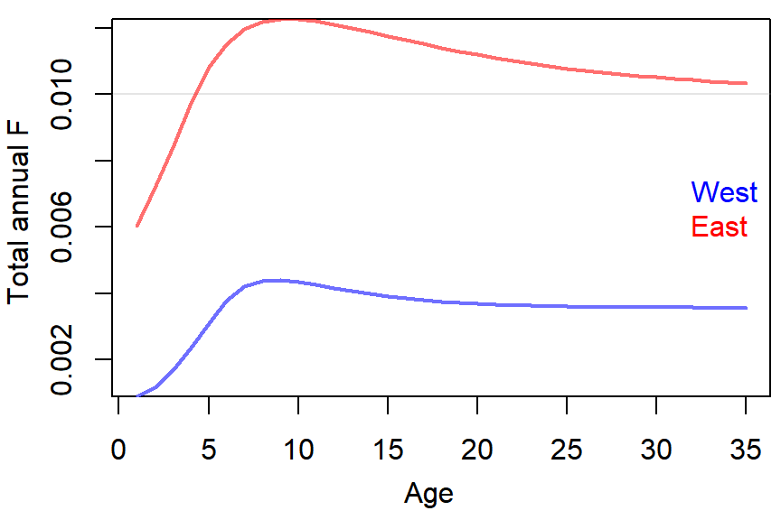

Figure 8. The current profile of F at age summed over all fleets, average weighed (by total contribution to annual F) over seasons and areas.

# 10 Estimated size selectivity

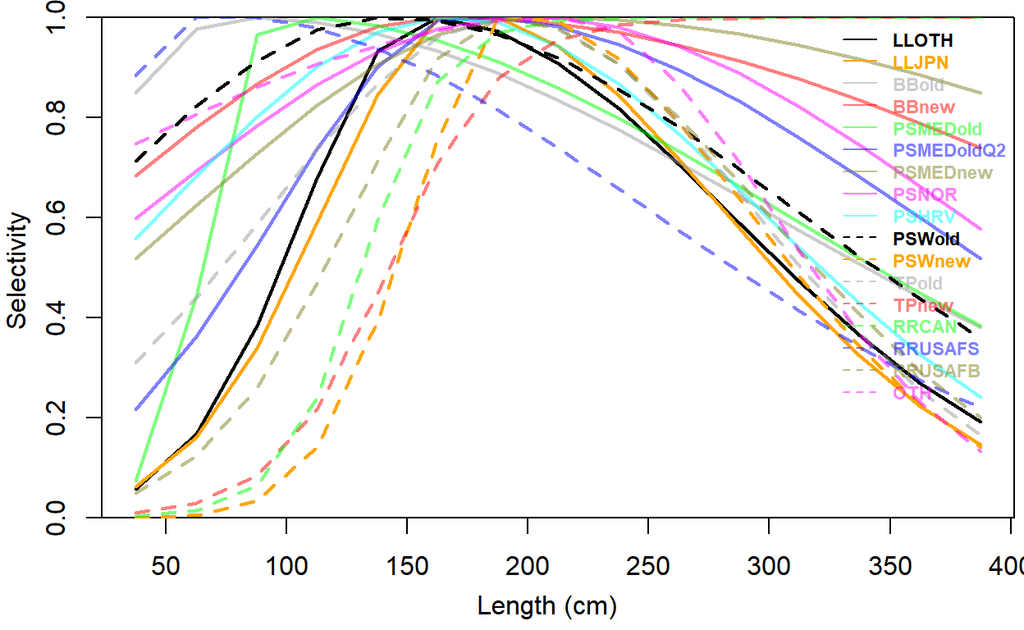

Figure 9. The size selectivity of the various fishing fleets included in the operating model.

# 11 Fit to aggregate catches

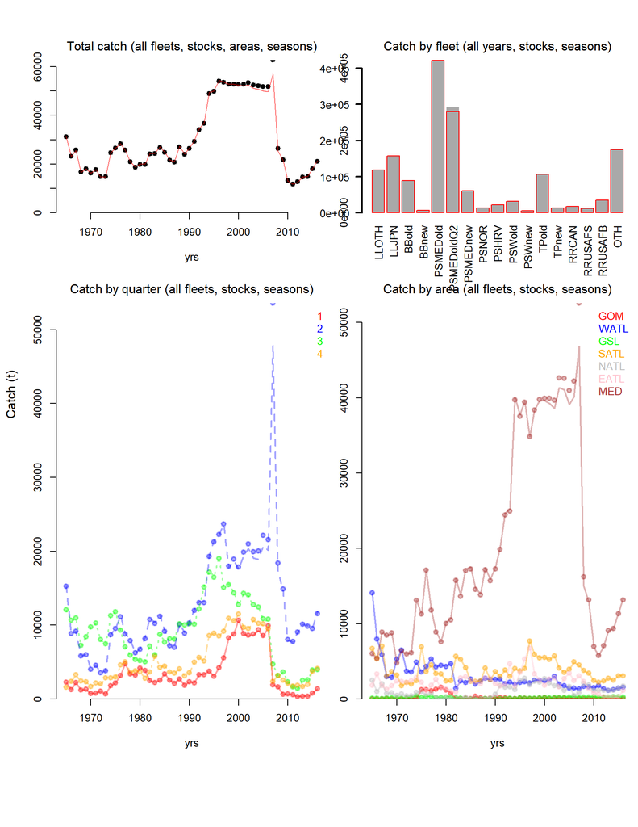

Figure 10. Fit to a observed total catches (tons) aggregated over various axes (lines = predicted, points = observed)

# 12 Fit to length composition

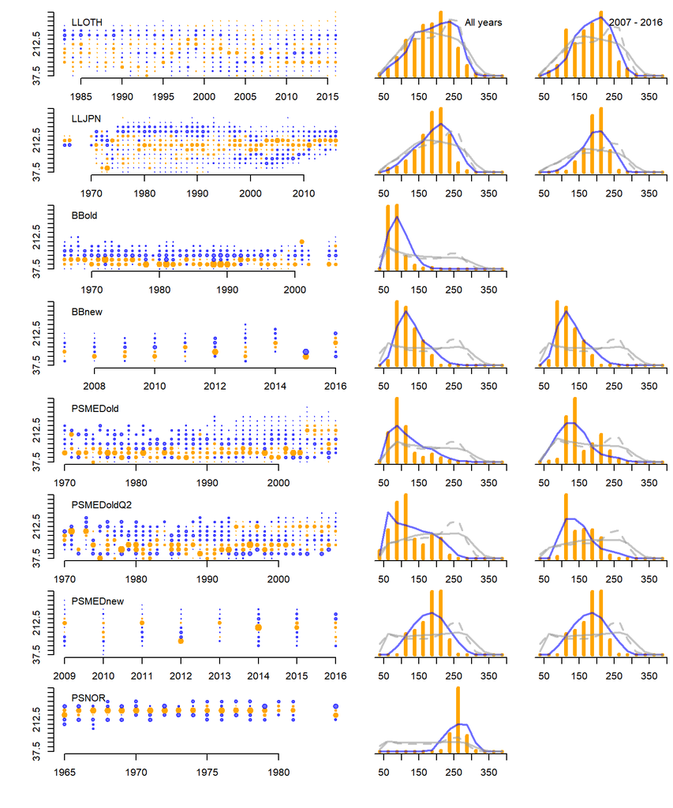

Figure 11.Length composition residuals. The left-hand panels show residuals over time. Orange circles are positive residuals (observed proportion is higher than expected), blue circles are negative residuals. The area of the circle is proportional to the absolute residuals error (i.e. if the observed proportion of a length class is 0.5 and the model predicted fraction is 0.4, this is represented by a circle ten time larger than if the observed proportion was 0.05 and the predicted fraction is 0.04). This keeps the scaling of the left-hand plots the same as the right-hand plots that show the aggregate residual error over all years and (right mosts panels) the period since 2007. Given the estimated selectivity of each fleet, the grey lines show the predicted composition of catches for a hypothetical unfished Eastern stock (solid grey line) and a hypothetical unfished western stock (dashed grey line).

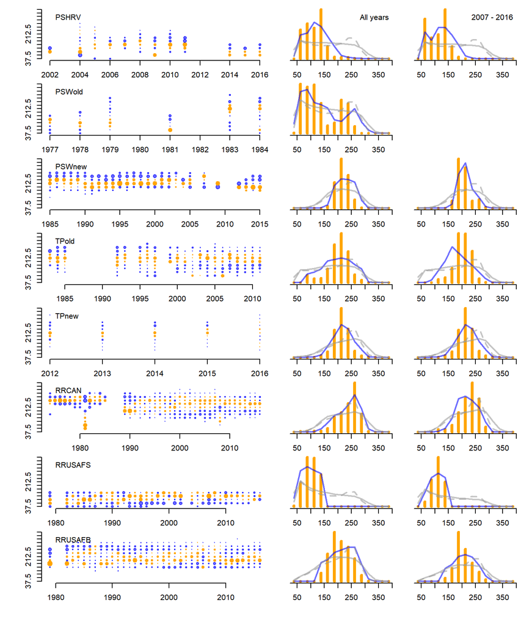

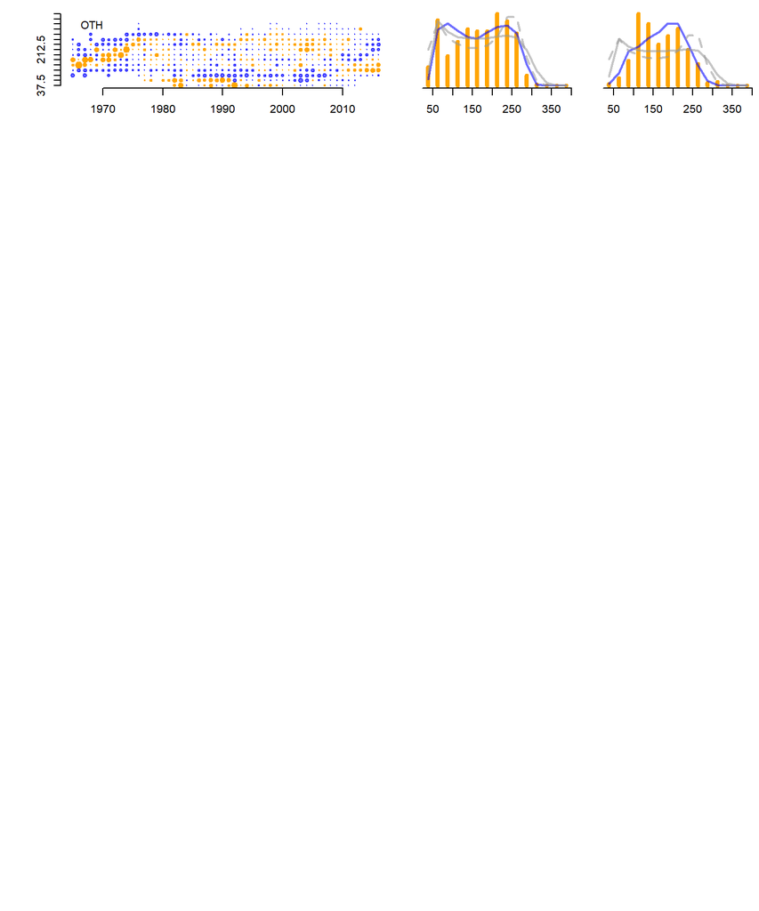

Figure 11 cont. Length composition residuals.

# 13 Spatial distribution

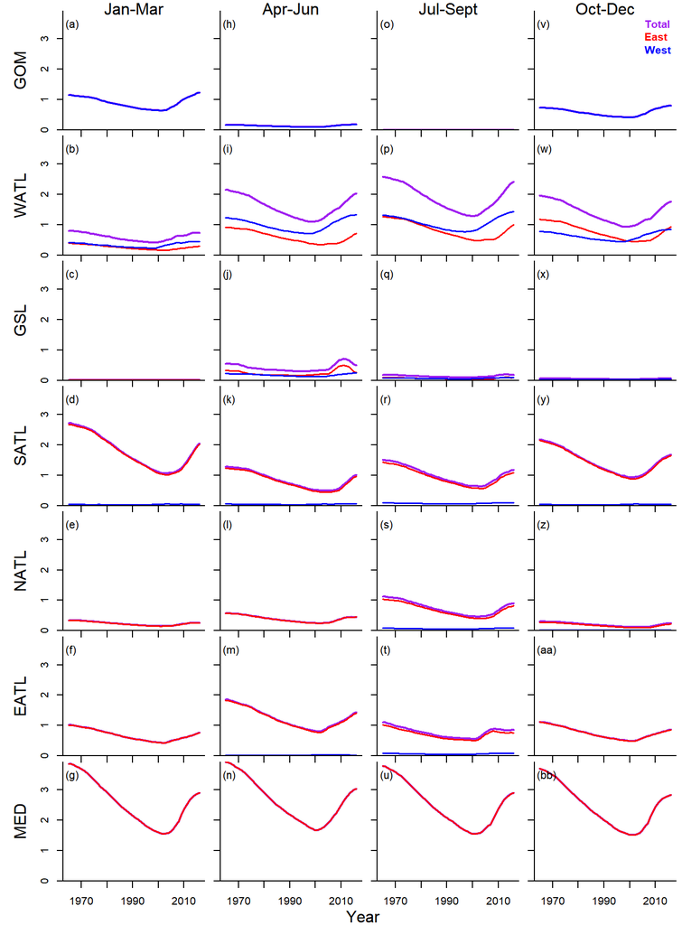

Figure 12. The predicted seasonal and spatial biomass of Atlantic bluefin tuna by stock.

# 14 Estimated unfished movement

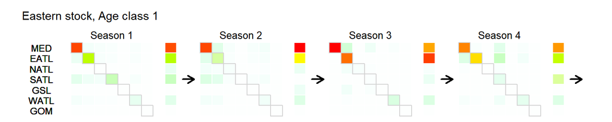

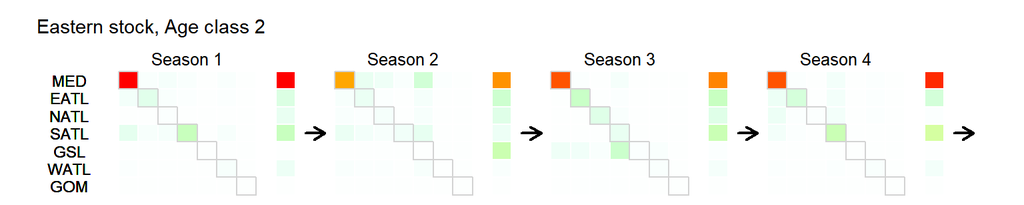

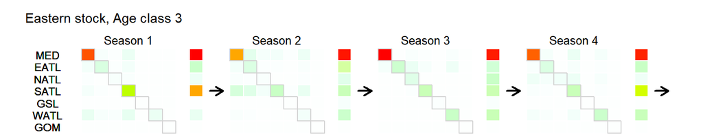

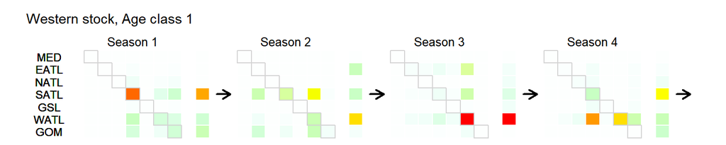

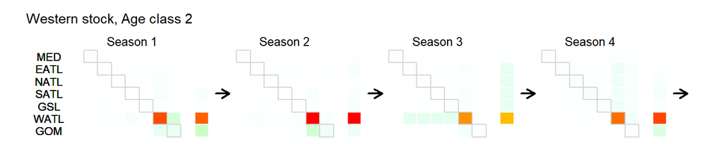

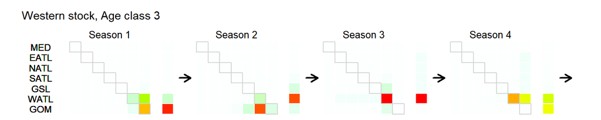